# TFM - Estudi demogràfic

Salvador Sanchis Beneseit

January 6, 2024

## 1. Data loading and preprocessing

We load the data:

```r
clinic <- read.csv("clinic.csv", sep=",")
```

We filter our variables of interest, only from ms patients, into `clinic_data` :

```r
clinic_ms <- subset(clinic, controls_ms == 1)
columns_to_keep <- c("id", "age", "sex", "dd", "mstype","edss")
clinic_data <- clinic_ms[, columns_to_keep]
```

```r
summary(clinic_data)
```

```
##       id                 age             sex               dd
##  Length:147         Min.   :22.66   Min.   :0.0000   Min.   : 2.72
##  Class :character   1st Qu.:39.91   1st Qu.:0.0000   1st Qu.: 9.25
##  Mode  :character   Median :46.68   Median :0.0000   Median :13.92
##                     Mean   :47.33   Mean   :0.2925   Mean   :15.96
##                     3rd Qu.:54.39   3rd Qu.:1.0000   3rd Qu.:20.29
##                     Max.   :72.22   Max.   :1.0000   Max.   :46.13
##      mstype            edss
##  Min.   :0.0000   Min.   :0.00
##  1st Qu.:0.0000   1st Qu.:1.50
##  Median :0.0000   Median :2.00
##  Mean   :0.1905   Mean   :2.66
##  3rd Qu.:0.0000   3rd Qu.:3.50
##  Max.   :2.0000   Max.   :7.50
```

We check and correct data formats:

```r
sapply(clinic_data, class)
```

```
##          id         age         sex          dd      mstype        edss
## "character"   "numeric"   "integer"   "numeric"   "integer"   "numeric"
```

```r
clinic_data$sex[clinic_data$sex == 0] <- "F"
clinic_data$sex[clinic_data$sex == 1] <- "M"
clinic_data$sex <- as.factor(clinic_data$sex)
levels(clinic_data$sex)
```

```
## [1] "F" "M"
```

```r
clinic_data$mstype[clinic_data$mstype == 0] <- "RRMS"
clinic_data$mstype[clinic_data$mstype == 1] <- "SPMS"
clinic_data$mstype[clinic_data$mstype == 2] <- "PPMS"
clinic_data$mstype <- as.factor(clinic_data$mstype)
levels(clinic_data$mstype)
```

```
## [1] "PPMS" "RRMS" "SPMS"
```

```r
sapply(clinic_data, class)
```

```
##          id         age         sex          dd      mstype        edss
## "character"   "numeric"    "factor"   "numeric"    "factor"   "numeric"
```

## 2. Visual inspection of data

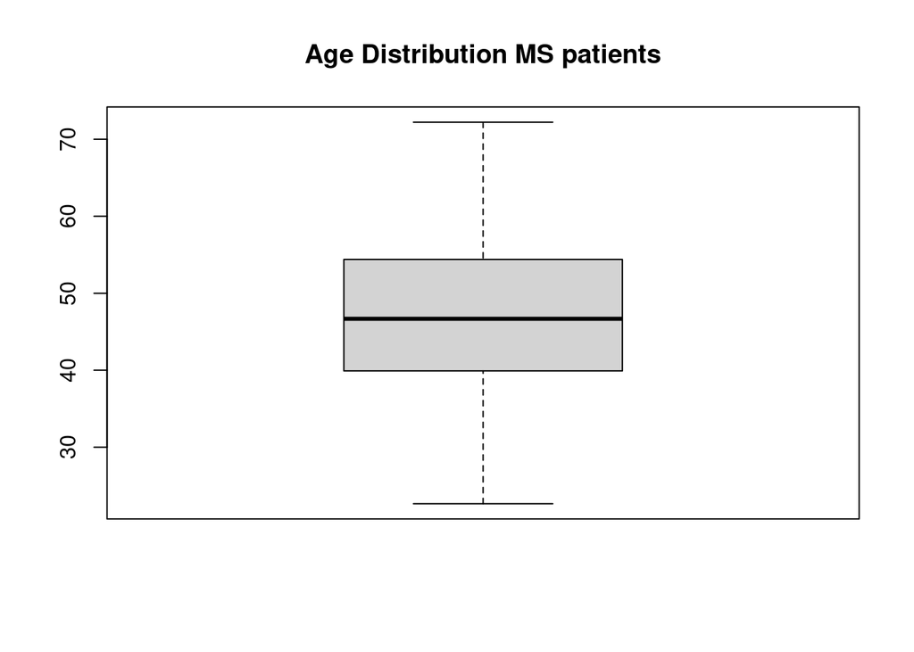

```r
boxplot(clinic_data$age, main="Age Distribution MS patients")
```

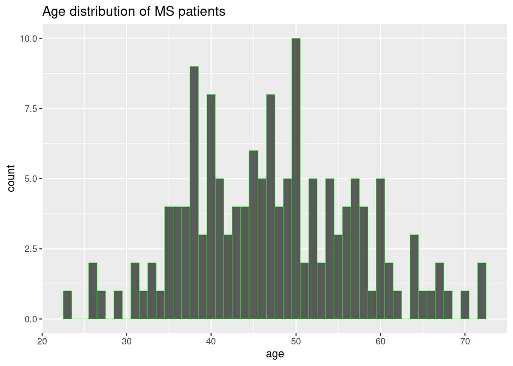

```r
library(ggplot2)
ageplot <- ggplot(clinic_data, aes(age))
ageplot +geom_histogram(binwidth = 1, colour = 'green', size=0.2) + ggtitle("Age distribution of MS patients")
```

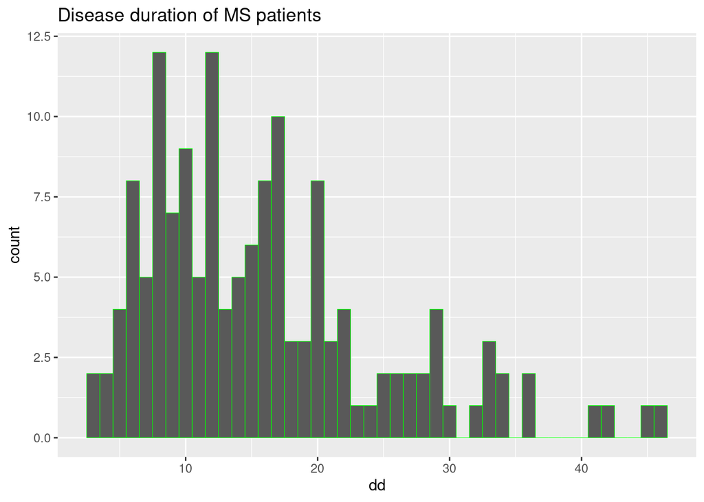

```r
ddplot <- ggplot(clinic_data, aes(dd))
ddplot +geom_histogram(binwidth = 1, colour = 'green', size=0.2) + ggtitle("Disease duration of MS patients")
```

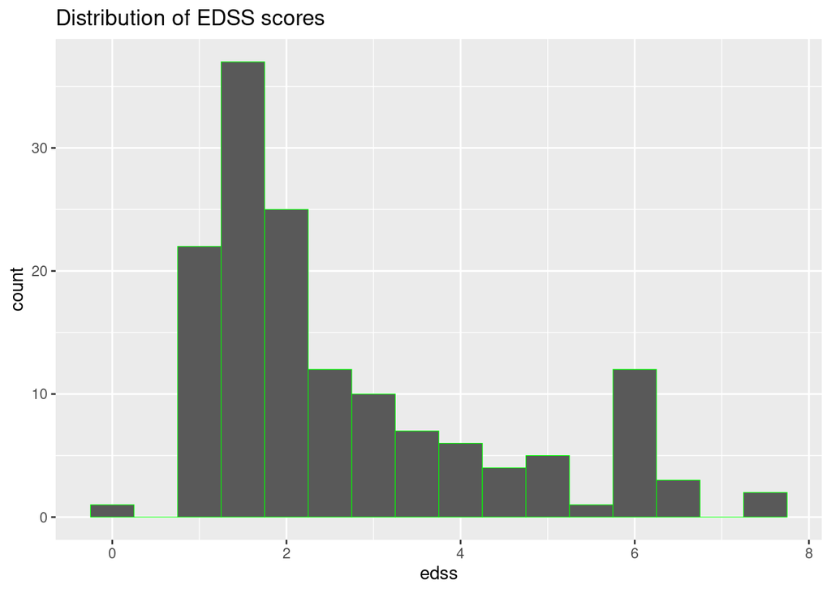

```r
edssplot <- ggplot(clinic_data, aes(edss))
edssplot +geom_histogram(binwidth = 0.5, colour = 'green', size=0.2) + ggtitle("Distribution of EDSS scores")
```

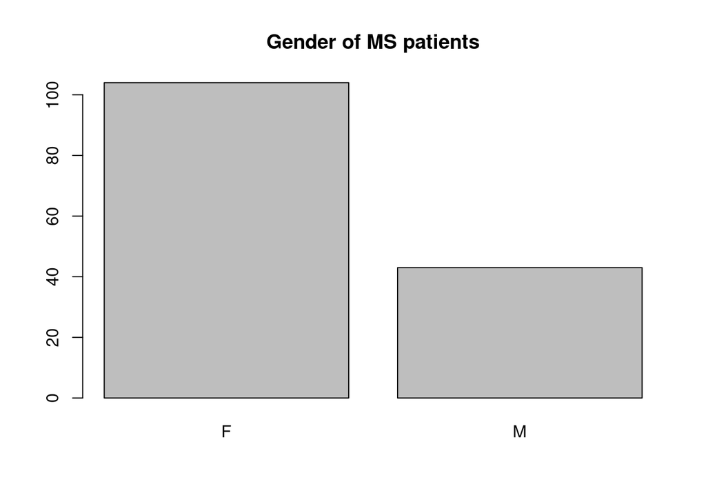

```r
gender_count <- table(clinic_data$sex)
barplot(gender_count, main="Gender of MS patients")
```

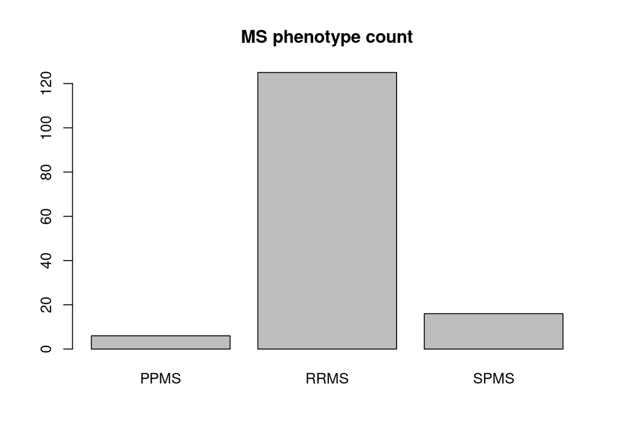

```r
ms_type_count <- table(clinic_data$mstype)
barplot(ms_type_count, main="MS phenotype count")
```

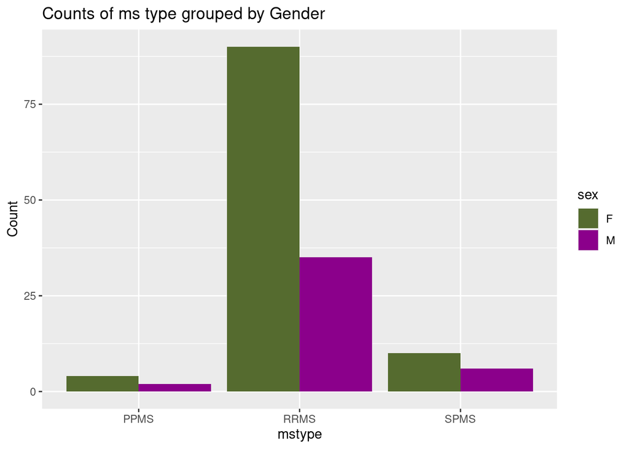

```r
ggplot(clinic_data, aes(x = mstype, fill = sex)) +
  geom_bar(position = "dodge", stat = "count") +
  labs(title = "Counts of ms type grouped by Gender", x = "mstype", y = "Count") +
  scale_fill_manual(values = c("darkolivegreen", "darkmagenta"))
```

In this plot we see no pattern to the correlation between disease duration and EDSS score:

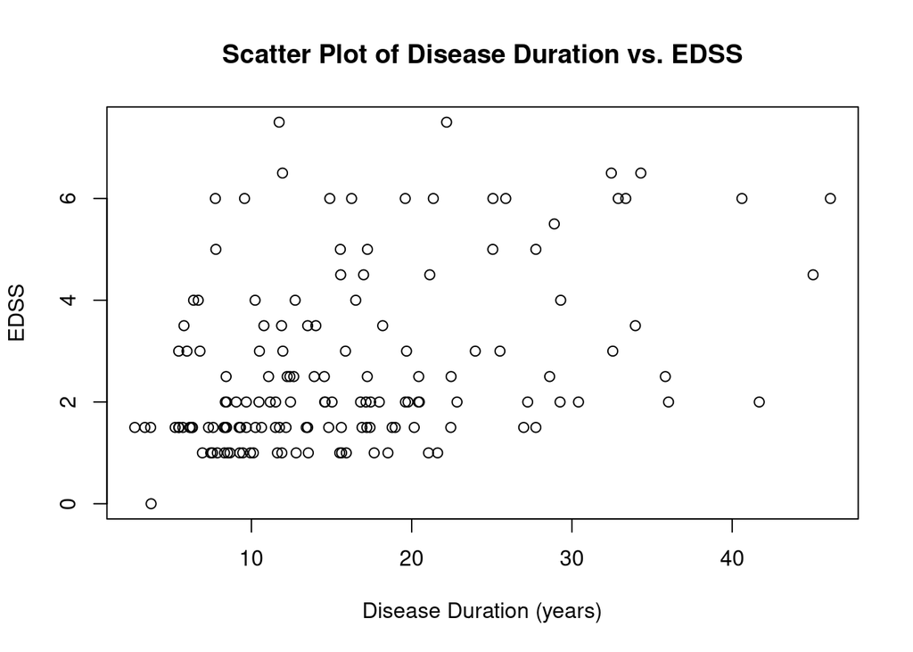

```r
plot(clinic_data$dd, clinic_data$edss,
     main = "Scatter Plot of Disease Duration vs. EDSS",
     xlab = "Disease Duration (years)",
     ylab = "EDSS")
```

However, introducing phenotype information, we see that high edss scores correspond mainly to PPMS and SPMS types, with lower and higher disease duration respectively:

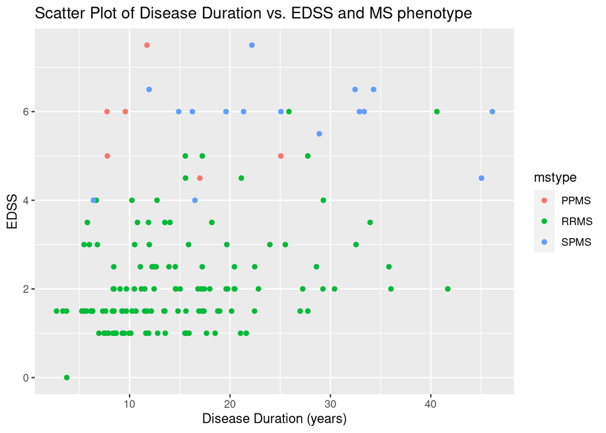

```r
ggplot(clinic_data, aes(x = dd, y = edss, color = mstype)) +
  geom_point() +
  labs(title = "Scatter Plot of Disease Duration vs. EDSS and MS phenotype",
       x = "Disease Duration (years)",
       y = "EDSS")
```

In the following cells, we explore relations between brain volumes, EDSS and type of disease. Following our state of the art preliminary work, we are curious about the role of atrophy of the thalamus in MS.

```r
# We subset data from left and right thalamus and we eliminate outliers
volumes_controls <- read.csv('volum_nodes_controls.csv')
rownames(volumes_controls) <- volumes_controls$X0
volumes_controls <- volumes_controls[, -1]

volumes_patients <- read.csv('volum_nodes_patients.csv')
rownames(volumes_patients) <- volumes_patients$X0
volumes_patients <- volumes_patients[, -1]

all_volumes <- rbind(volumes_patients, volumes_controls)

clinic_data['avg_volumes'] <- rowMeans(volumes_patients)

thalamus_all <- all_volumes[, c('X32', 'X39')]
```

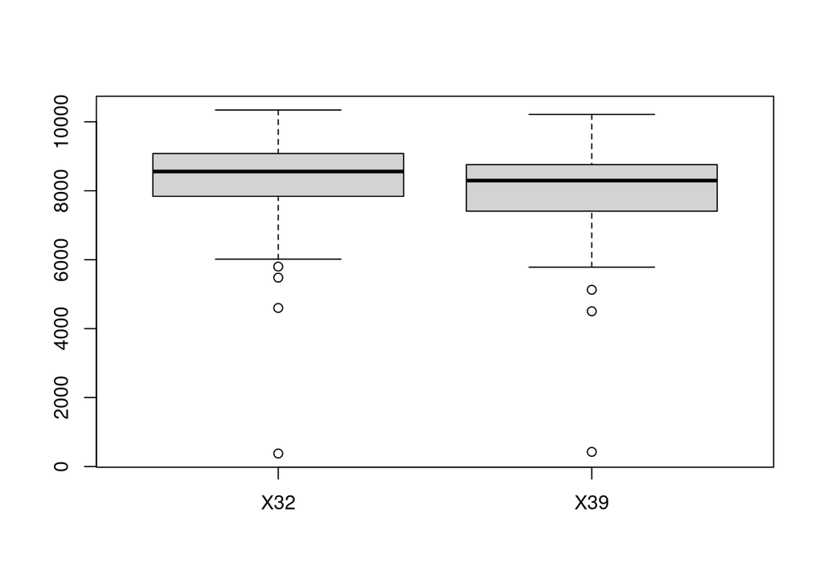

```r
boxplot(thalamus_all)
```

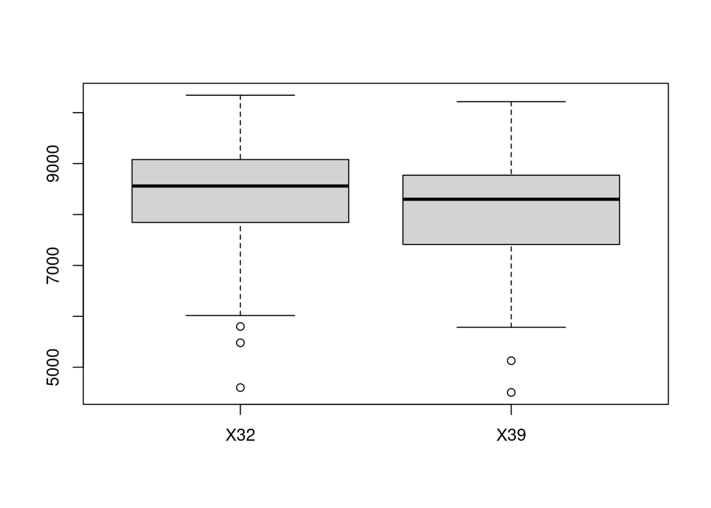

```r
outlier <- which.min(thalamus_all$X39)
thalamus_corrected <- thalamus_all[-outlier, ]
boxplot(thalamus_corrected)
```

```r
clinic_data_th <- clinic_data[-78, ]
clinic_data_th['left_thalamus'] <- thalamus_corrected$X32[1:146]
clinic_data_th['right_thalamus'] <- thalamus_corrected$X39[1:146]
clinic_data_th['thal_avg'] <- (clinic_data_th$right_thalamus + clinic_data_th$left_thalamus) / 2
```

In this plot we relate average brain volumes (all 76 nodes) with EDSS and disease phenotype:

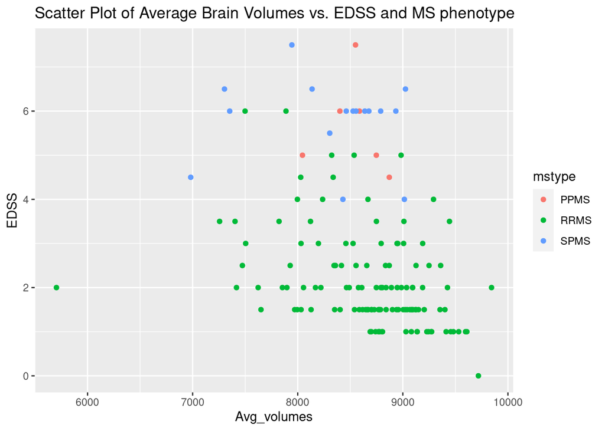

```r
library(ggplot2)
ggplot(clinic_data_th, aes(x = avg_volumes, y = edss, color = mstype)) +
  geom_point() +
  labs(title = "Scatter Plot of Average Brain Volumes vs. EDSS and MS phenotype",
       x = "Avg_volumes",
       y = "EDSS")
```

Next, we do similar comparison, but this time using only thalamic volumes (we switch the axes of the visualization):

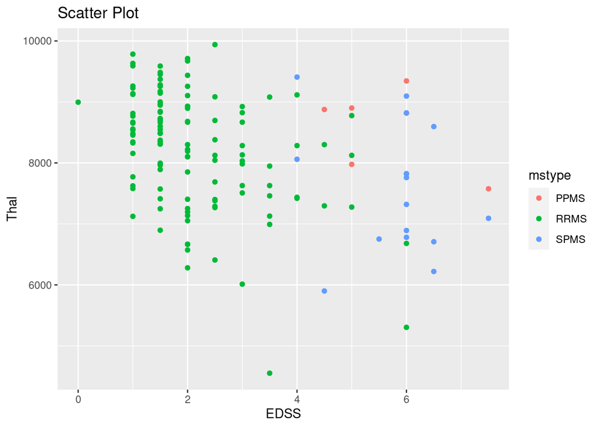

```r
ggplot(clinic_data_th, aes(x = edss, y = thal_avg, color = mstype)) +
  geom_point() +
  labs(title = "Scatter Plot",
       x = "EDSS",
       y = "Thal")
```

As the 2 previous visualizations are inconclusive, we show a comparison of boxplots for the different levels of EDSS in relation to thalamic volume:

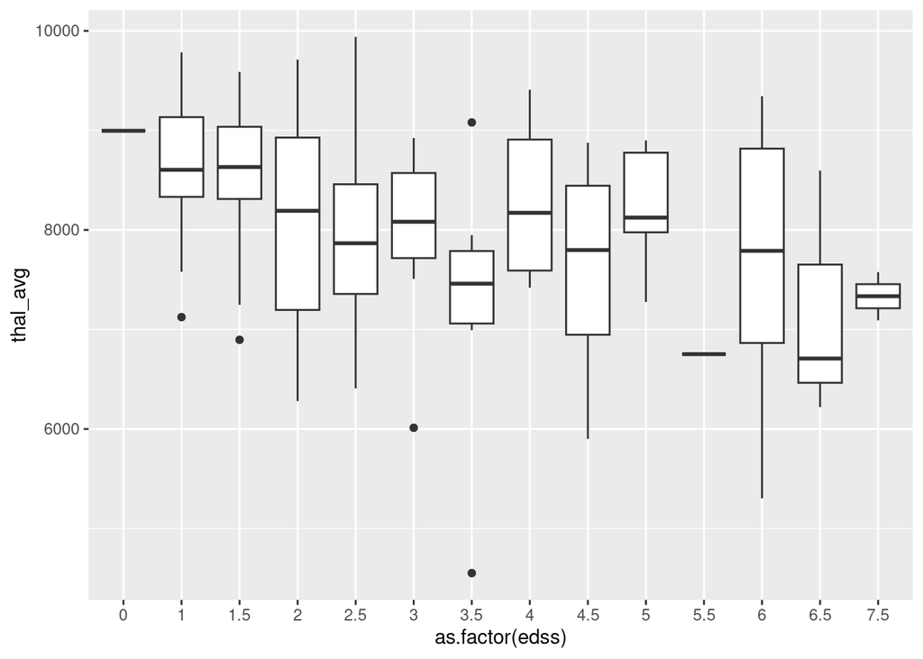

```r
ggplot(aes(y=thal_avg, x=as.factor(edss)), data=clinic_data_th) + geom_boxplot()
```

Since we perceive a slightly descending trend in the graph, we decide to do an ANOVA test to see if there is a significant relation between thalamic volumes and EDSS. The results show that this is indeed the case (p=0.0025), so we will include thalamic volumes in our classification task.

```r
lm_thal <- lm(thal_avg~as.factor(edss), data = clinic_data_th)
table_anova <- anova(lm_thal)
table_anova
```

```
## Analysis of Variance Table
##
## Response: thal_avg
##                  Df    Sum Sq Mean Sq F value Pr(>F)
## as.factor(edss)  13  28154059 2165697  2.6532 0.0025 **
## Residuals       132 107746976  816265
## ---
## Signif. codes:  0 '***' 0.001 '**' 0.01 '*' 0.05 '.' 0.1 ' ' 1
```

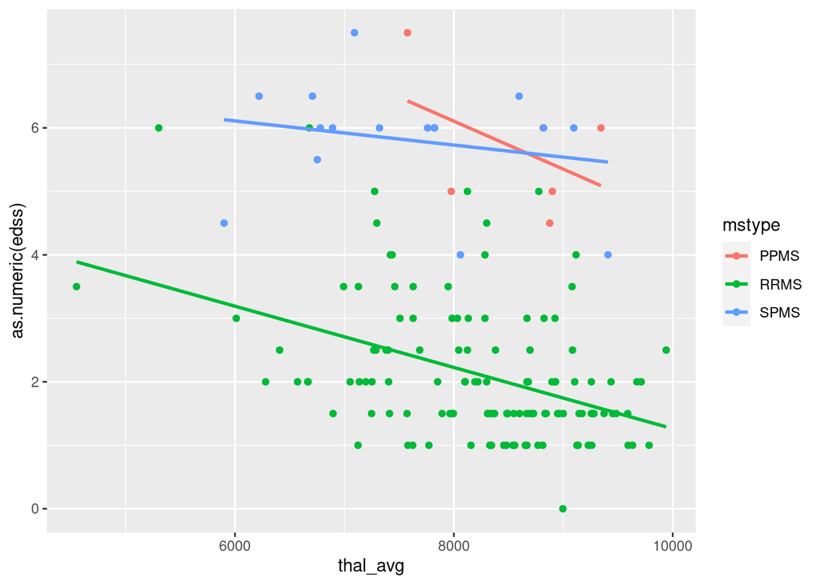

```r
ggplot(clinic_data_th, aes(x = thal_avg, y = as.numeric(edss), color = mstype)) +
  geom_point() + geom_smooth(method = 'lm', se=FALSE)
```

## 3. Statistical measures

In the following cells, we describe groups and study their statistical differences (patients vs. controls, and disease phenotype groups) in terms of age, disease duration, EDSS and gender. All results are summarized on a table in the last section of this notebook.

```r
#we define a function to calculate median and iqr
calculate_summary_stats <- function(data, condition) {
  vector <- condition
  result <- list(
    median = median(vector),
    q1 = quantile(vector, 0.25),
    q3 = quantile(vector, 0.75)
  )
  formatted_result <- sprintf("%.2f (%.2f - %.2f)", result$median, result$q1, result$q3)

  return(formatted_result)
}
```

### Age

```r
hc_age <- calculate_summary_stats(clinic, clinic$age[clinic$controls_ms == 0])
rrms_age <- calculate_summary_stats(clinic_data, clinic_data$age[clinic_data$mstype == "RRMS"])
spms_age <- calculate_summary_stats(clinic_data, clinic_data$age[clinic_data$mstype == "SPMS"])
ppms_age <- calculate_summary_stats(clinic_data, clinic_data$age[clinic_data$mstype == "PPMS"])

hc_age
```

```
## [1] "36.25 (28.64 - 43.18)"
```

```r
rrms_age
```

```
## [1] "45.28 (38.21 - 51.00)"
```

```r
spms_age
```

```
## [1] "53.80 (50.59 - 65.27)"
```

```r
ppms_age
```

```
## [1] "56.81 (55.90 - 57.91)"
```

```r
hc_age_data <- clinic$age[clinic$controls_ms == 0]
ms_age_data <- clinic$age[clinic$controls_ms == 1]

wilcoxon_age <- wilcox.test(hc_age_data, ms_age_data)
formatted_p_value_w <- ifelse(wilcoxon_age$p.value < 0.001, "p < 0.001", sprintf("p = %.3f", wilcoxon_age$p.value))
wilcoxon_age_p <- c(wilcoxon_age, Formatted_P_Value = formatted_p_value_w)
wilcoxon_age_p
```

```
## $statistic
##   W
## 605
##
## $parameter
## NULL
##
## $p.value
## [1] 0.0001766345
##
## $null.value
## location shift
##              0
##
## $alternative
## [1] "two.sided"
##
## $method
## [1] "Wilcoxon rank sum test with continuity correction"
##
## $data.name
## [1] "hc_age_data and ms_age_data"
##
## $Formatted_P_Value
## [1] "p < 0.001"
```

```r
rrms_age_data <- clinic_data$age[clinic_data$mstype == "RRMS"]
spms_age_data <- clinic_data$age[clinic_data$mstype == "SPMS"]
ppms_age_data <- clinic_data$age[clinic_data$mstype == "PPMS"]

# Kruskal-Wallis test
kruskal_age <- kruskal.test(list(rrms_age_data, spms_age_data, ppms_age_data))
formatted_p_value <- ifelse(kruskal_age$p.value < 0.001, "p < 0.001", sprintf("p = %.3f", kruskal_age$p.value))
kruskal_age_p <- c(kruskal_age, Formatted_P_Value = formatted_p_value)
kruskal_age_p
```

```
## $statistic
## Kruskal-Wallis chi-squared
##                   21.71581
##
## $parameter
## df
##  2
##
## $p.value
## [1] 1.925181e-05
##
## $method
## [1] "Kruskal-Wallis rank sum test"
##
## $data.name
## [1] "list(rrms_age_data, spms_age_data, ppms_age_data)"
##
## $Formatted_P_Value
## [1] "p < 0.001"
```

```r
library(dunn.test)

# Perform Dunn's test for pairwise comparisons
dunn_age <- dunn.test(list(rrms_age_data, spms_age_data, ppms_age_data), method = "bonferroni")
```

```
##   Kruskal-Wallis rank sum test
##
## data: x and group
## Kruskal-Wallis chi-squared = 21.7158, df = 2, p-value = 0
##
##
##                            Comparison of x by group
##                                  (Bonferroni)
## Col Mean-|
## Row Mean |          1          2
## ---------+----------------------
##        2 |  -3.844563
##          |    0.0002*
##        3 |  -2.903777  -0.402699
##          |    0.0055*     1.0000
##
## alpha = 0.05
## Reject Ho if p <= alpha/2
```

```r
# The results show difference between groups, except for comparison between spms and ppms
dunn_age
```

```
## $chi2
## [1] 21.71581
##
## $Z
## [1] -3.8445635 -2.9037778 -0.4026996
##
## $P
## [1] 6.038359e-05 1.843449e-03 3.435846e-01
##
## $P.adjusted
## [1] 0.0001811508 0.0055303459 1.0000000000
##
## $comparisons
## [1] "1 - 2" "1 - 3" "2 - 3"
```

### Disease duration

```r
rrms_dd <- calculate_summary_stats(clinic_data, clinic_data$dd[clinic_data$mstype == "RRMS"])
spms_dd <- calculate_summary_stats(clinic_data, clinic_data$dd[clinic_data$mstype == "SPMS"])
ppms_dd <- calculate_summary_stats(clinic_data, clinic_data$dd[clinic_data$mstype == "PPMS"])

rrms_dd
```

```
## [1] "12.79 (8.66 - 18.78)"
```

```r
spms_dd
```

```
## [1] "23.62 (16.45 - 33.01)"
```

```r
ppms_dd
```

```
## [1] "10.65 (8.23 - 15.68)"
```

```r
rrms_dd_data <- clinic_data$dd[clinic_data$mstype == "RRMS"]
spms_dd_data <- clinic_data$dd[clinic_data$mstype == "SPMS"]
ppms_dd_data <- clinic_data$dd[clinic_data$mstype == "PPMS"]

# Kruskal-Wallis test
kruskal_dd <- kruskal.test(list(rrms_dd_data, spms_dd_data, ppms_dd_data))
formatted_p_value_dd <- ifelse(kruskal_dd$p.value < 0.001, "p < 0.001", sprintf("p = %.3f", kruskal_dd$p.value))
kruskal_dd_p <- c(kruskal_dd, Formatted_P_Value = formatted_p_value_dd)
kruskal_dd_p
```

```
## $statistic
## Kruskal-Wallis chi-squared
##                   13.97348
##
## $parameter
## df
##  2
##
## $p.value
## [1] 0.0009240545
##
## $method
## [1] "Kruskal-Wallis rank sum test"
##
## $data.name
## [1] "list(rrms_dd_data, spms_dd_data, ppms_dd_data)"
##
## $Formatted_P_Value
## [1] "p < 0.001"
```

```r
# Perform Dunn's test for pairwise comparisons
dunn_dd <- dunn.test(list(rrms_dd_data, spms_dd_data, ppms_dd_data), method = "bonferroni")
```

```
##   Kruskal-Wallis rank sum test
##
## data: x and group
## Kruskal-Wallis chi-squared = 13.9735, df = 2, p-value = 0
##
##
##                            Comparison of x by group
##                                  (Bonferroni)
## Col Mean-|
## Row Mean |          1          2
## ---------+----------------------
##        2 |  -3.653034
##          |    0.0004*
##        3 |   0.527559   2.486730
##          |     0.8967    0.0193*
##
## alpha = 0.05
## Reject Ho if p <= alpha/2
```

```r
# The results show difference between groups, except for comparison between rrms and ppms
dunn_dd
```

```
## $chi2
## [1] 13.97348
##
## $Z
## [1] -3.6530347  0.5275597  2.4867304
##
## $P
## [1] 0.0001295796 0.2989024804 0.0064461526
##
## $P.adjusted
## [1] 0.0003887388 0.8967074411 0.0193384578
##
## $comparisons
## [1] "1 - 2" "1 - 3" "2 - 3"
```

### EDSS

```r
rrms_edss <- calculate_summary_stats(clinic_data, clinic_data$edss[clinic_data$mstype == "RRMS"])

spms_edss <- calculate_summary_stats(clinic_data, clinic_data$edss[clinic_data$mstype == "SPMS"])

ppms_edss <- calculate_summary_stats(clinic_data, clinic_data$edss[clinic_data$mstype == "PPMS"])

spms_edss
```

```
## [1] "6.00 (5.88 - 6.12)"
```

```r
rrms_edss
```

```
## [1] "2.00 (1.50 - 2.50)"
```

```r
ppms_edss
```

```
## [1] "5.50 (5.00 - 6.00)"
```

```r
rrms_edss_data <- clinic_data$edss[clinic_data$mstype == "RRMS"]
spms_edss_data <- clinic_data$edss[clinic_data$mstype == "SPMS"]
ppms_edss_data <- clinic_data$edss[clinic_data$mstype == "PPMS"]

# Kruskal-Wallis test
kruskal_edss <- kruskal.test(list(rrms_edss_data, spms_edss_data, ppms_edss_data))
formatted_p_value_edss <- ifelse(kruskal_edss$p.value < 0.001, "p < 0.001", sprintf("p = %.3f", kruskal_edss$p.value))
kruskal_edss_p <- c(kruskal_edss, Formatted_P_Value = formatted_p_value_edss)
kruskal_edss_p
```

```
## $statistic
## Kruskal-Wallis chi-squared
##                   53.22723
##
## $parameter
## df
##  2
##
## $p.value
## [1] 2.766016e-12
##
## $method
## [1] "Kruskal-Wallis rank sum test"
##
## $data.name
## [1] "list(rrms_edss_data, spms_edss_data, ppms_edss_data)"
##
## $Formatted_P_Value
## [1] "p < 0.001"
```

```r
# Perform Dunn's test for pairwise comparisons
dunn_edss <- dunn.test(list(rrms_edss_data, spms_edss_data, ppms_edss_data), method = "bonferroni")
```

```
##   Kruskal-Wallis rank sum test
##
## data: x and group
## Kruskal-Wallis chi-squared = 53.2272, df = 2, p-value = 0
##
##
##                            Comparison of x by group
##                                  (Bonferroni)
## Col Mean-|
## Row Mean |          1          2
## ---------+----------------------
##        2 |  -6.406047
##          |    0.0000*
##        3 |  -3.944131   0.109766
##          |    0.0001*     1.0000
##
## alpha = 0.05
## Reject Ho if p <= alpha/2
```

```r
# The results show difference between groups, except for comparison between spms and ppms
dunn_edss
```

```
## $chi2
## [1] 53.22723
##
## $Z
## [1] -6.4060471 -3.9441311  0.1097668
##
## $P
## [1] 7.467044e-11 4.004492e-05 4.562972e-01
##
## $P.adjusted
## [1] 2.240113e-10 1.201348e-04 1.000000e+00
##
## $comparisons
## [1] "1 - 2" "1 - 3" "2 - 3"
```

### Gender

```r
calculate_gender_stats <- function(data, group_column, gender_column, group_value) {
  # Subset data for the specified group
  group_data <- data[data[[group_column]] == group_value, ]

  # Count of females
  female_count <- sum(group_data[[gender_column]] == 0 | group_data[[gender_column]] == "F")

  total_count <- nrow(group_data)
  # Percentage of females
  female_percentage <- (female_count / total_count) * 100

  result <- list(
    Female_Count = female_count,
    Female_Percentage = female_percentage
  )
  formatted_result <- sprintf("%d (%.f%%)", result$Female_Count, result$Female_Percentage)

  return(formatted_result)
}
```

```r
female_hv <- calculate_gender_stats(clinic, "controls_ms", "sex", 0)
female_rrms <- calculate_gender_stats(clinic_data, "mstype", "sex", "RRMS")
female_spms <- calculate_gender_stats(clinic_data, "mstype", "sex", "SPMS")
female_ppms <- calculate_gender_stats(clinic_data, "mstype", "sex", "PPMS")
female_hv
```

```
## [1] "15 (83%)"
```

```r
female_rrms
```

```
## [1] "90 (72%)"
```

```r
female_spms
```

```
## [1] "10 (62%)"
```

```r
female_ppms
```

```
## [1] "4 (67%)"
```

```r
gender_table_controls <- table(clinic$controls_ms == 0, clinic$sex)
gender_table_controls
```

```
##
##           0   1
##   FALSE 104  43
##   TRUE   15   3
```

```r
chi_sq_ms <- chisq.test(gender_table_controls)
chi_sq_ms
```

```
##
##  Pearson's Chi-squared test with Yates' continuity correction
##
## data:  gender_table_controls
## X-squared = 0.71483, df = 1, p-value = 0.3978
```

```r
gender_table_phenotypes <- table(clinic_data$mstype, clinic_data$sex)
gender_table_phenotypes
```

```
##
##         F  M
##   PPMS  4  2
##   RRMS 90 35
##   SPMS 10  6
```

```r
chi_sq_types <- chisq.test(gender_table_phenotypes)
chi_sq_types
```

```
##
##  Pearson's Chi-squared test
##
## data:  gender_table_phenotypes
## X-squared = 0.66893, df = 2, p-value = 0.7157
```

## Summary

```r
summary_table <- data.frame(HCs=c(hc_age, "-", "-", female_hv),
                            RRMS=c(rrms_age, rrms_dd, rrms_edss, female_rrms),
                            SPMS=c(spms_age, spms_dd, spms_edss, female_spms),
                            PPMS=c(ppms_age, ppms_dd, ppms_edss, female_ppms),
                            p_value_HC_vs_MS=c(wilcoxon_age_p$Formatted_P_Value, "-", "-", round(chi_sq_ms$p.value, 3)),
                            p_value_MS_types=c(kruskal_age_p$Formatted_P_Value, kruskal_dd_p$Formatted_P_Value, kruskal_edss_p$Formatted_P_Value, round(chi_sq_types$p.value, 3)),
                            row.names = c('Age(IQR)', 'Disease duration', 'EDSS', 'Female(%)'))

summary_table
```

```
##                                    HCs                  RRMS
## Age(IQR)         36.25 (28.64 - 43.18) 45.28 (38.21 - 51.00)
## Disease duration                     -  12.79 (8.66 - 18.78)
## EDSS                                 -    2.00 (1.50 - 2.50)
## Female(%)                     15 (83%)              90 (72%)
##                                   SPMS                  PPMS p_value_HC_vs_MS
## Age(IQR)         53.80 (50.59 - 65.27) 56.81 (55.90 - 57.91)        p < 0.001
## Disease duration 23.62 (16.45 - 33.01)  10.65 (8.23 - 15.68)                -
## EDSS                6.00 (5.88 - 6.12)    5.50 (5.00 - 6.00)                -
## Female(%)                     10 (62%)               4 (67%)            0.398
##                  p_value_MS_types
## Age(IQR)                p < 0.001
## Disease duration        p < 0.001
## EDSS                    p < 0.001
## Female(%)                   0.716
```